# Soluciones 6

Sergio Camiz

2025-05-27

## 1 Construir una carpeta Ejercicio 6

## 2 Con los datos de Linnerud

hacer la regresión de Jumps con respecto a las otras variables, seleccionar el mejor modelo y aplicar todos los diagnósticos (SIN el test de independencia que no tiene sentido) viendo si estos cumplen con todas las condiciones que se requieren.

*Cargamos los datos de Linnerud*

```r
lin                 <- read.csv("Linnerud.csv",row.names=1)
n                   <- dim(lin)[1]
p                   <- dim(lin)[2]
etiq                <- rownames(lin)
```

*Incluimos la función sum.lm que va ajuntar los intervales de confianza*

*Corremos el modelo completo y el step backwards*

```r
lm1                 <- lm(Jumps~.,data=lin)
sum.lm(lm1)
```

```
##
## Call:
## lm(formula = Jumps ~ ., data = lin)
##
## Residuals:
##     Min      1Q  Median      3Q     Max
## -56.726 -20.101  -0.372   9.893  95.929
##
## Coefficients:
##                           2.5 %    97.5 % Std. Error t value Pr(>|t|)
## (Intercept) -366.9666 -759.9213   25.9881   183.2139  -2.003  0.06494 .
## Weight        -1.2208   -2.7307    0.2891     0.7040  -1.734  0.10486
## Waist         15.7181    2.3225   29.1137     6.2456   2.517  0.02466 *
## Pulse         -0.4531   -3.1051    2.1989     1.2365  -0.366  0.71953
## Pulls          1.9467   -2.8643    6.7577     2.2431   0.868  0.40011
## Squats         0.7276    0.2875    1.1676     0.2052   3.546  0.00323 **
## ---
## Signif. codes:  0 '***' 0.001 '**' 0.01 '*' 0.05 '.' 0.1 ' ' 1
##
## Residual standard error: 36.02 on 14 degrees of freedom
## Multiple R-squared:  0.6364, Adjusted R-squared:  0.5066
## F-statistic: 4.901 on 5 and 14 DF,  p-value: 0.008432
```

```r
lm1b                <- step(lm1,direction = "backward")
```

```
## Start:  AIC=148.23
## Jumps ~ Weight + Waist + Pulse + Pulls + Squats
##
##          Df Sum of Sq   RSS    AIC
## - Pulse   1     174.2 18339 146.42
## - Pulls   1     977.2 19142 147.28
## <none>                18164 148.23
## - Weight  1    3901.5 22066 150.12
## - Waist   1    8217.5 26382 153.69
## - Squats  1   16314.8 34479 159.05
##
## Step:  AIC=146.42
## Jumps ~ Weight + Waist + Pulls + Squats
##
##          Df Sum of Sq   RSS    AIC
## - Pulls   1    1017.9 19357 145.50
## <none>                18339 146.42
## - Weight  1    3759.8 22099 148.15
## - Waist   1    8406.7 26745 151.97
## - Squats  1   16204.5 34543 157.09
##
## Step:  AIC=145.5
## Jumps ~ Weight + Waist + Squats
##
##          Df Sum of Sq   RSS    AIC
## <none>                19357 145.50
## - Weight  1    3272.2 22629 146.62
## - Waist   1    7519.0 26876 150.06
## - Squats  1   28037.2 47394 161.41
```

*Aplicamos el resultado proporcionado para step()*

```r
lm2                 <- lm(Jumps ~ Weight + Waist + Squats,data=lin)
sum.lm(lm2)
```

```
##
## Call:
## lm(formula = Jumps ~ Weight + Waist + Squats, data = lin)
##
## Residuals:
##     Min      1Q  Median      3Q     Max
## -51.999 -14.763  -2.173   4.021 101.545
##
## Coefficients:
##                           2.5 %    97.5 % Std. Error t value Pr(>|t|)
## (Intercept) -370.0294 -676.8865  -63.1724   144.7503  -2.556 0.021131 *
## Weight        -1.0974   -2.5120    0.3171     0.6673  -1.645 0.119548
## Waist         14.6132    2.1871   27.0394     5.8617   2.493 0.024009 *
## Squats         0.8177    0.4576    1.1778     0.1699   4.814 0.000191 ***
## ---
## Signif. codes:  0 '***' 0.001 '**' 0.01 '*' 0.05 '.' 0.1 ' ' 1
##
## Residual standard error: 34.78 on 16 degrees of freedom
## Multiple R-squared:  0.6125, Adjusted R-squared:  0.5399
## F-statistic: 8.432 on 3 and 16 DF,  p-value: 0.001372
```

```r
lm3                 <- lm(Jumps ~ Waist + Squats,data=lin)
sum.lm(lm3)
```

```
##
## Call:
## lm(formula = Jumps ~ Waist + Squats, data = lin)
##
## Residuals:
##     Min      1Q  Median      3Q     Max
## -42.984 -16.941  -4.381  10.076 114.705
##
## Coefficients:
##                           2.5 %    97.5 % Std. Error t value Pr(>|t|)
## (Intercept) -275.1090 -568.8867   18.6687   139.2433  -1.976 0.064646 .
## Waist          6.6050   -0.6168   13.8268     3.4230   1.930 0.070515 .
## Squats         0.7667    0.3971    1.1363     0.1752   4.377 0.000411 ***
## ---
## Signif. codes:  0 '***' 0.001 '**' 0.01 '*' 0.05 '.' 0.1 ' ' 1
##
## Residual standard error: 36.48 on 17 degrees of freedom
## Multiple R-squared:  0.547,  Adjusted R-squared:  0.4938
## F-statistic: 10.27 on 2 and 17 DF,  p-value: 0.001193
```

```r
anova(lm3,lm2)
```

```
## Analysis of Variance Table
##
## Model 1: Jumps ~ Waist + Squats
## Model 2: Jumps ~ Weight + Waist + Squats
##   Res.Df   RSS Df Sum of Sq      F Pr(>F)
## 1     17 22629
## 2     16 19357  1    3272.2 2.7048 0.1195
```

```r
library(car)
anova(lm2)
```

```
## Analysis of Variance Table
##
## Response: Jumps
##           Df  Sum Sq Mean Sq F value    Pr(>F)
## Weight     1  2558.3  2558.3  2.1147 0.1652254
## Waist      1     6.1     6.1  0.0050 0.9443792
## Squats     1 28037.2 28037.2 23.1753 0.0001908 ***
## Residuals 16 19356.6  1209.8
## ---
## Signif. codes:  0 '***' 0.001 '**' 0.01 '*' 0.05 '.' 0.1 ' ' 1
```

```r
Anova(lm2)
```

```
## Anova Table (Type II tests)
##
## Response: Jumps
##            Sum Sq Df F value    Pr(>F)
## Weight     3272.2  1  2.7048 0.1195483
## Waist      7519.0  1  6.2151 0.0240090 *
## Squats    28037.2  1 23.1753 0.0001908 ***
## Residuals 19356.6 16
## ---
## Signif. codes:  0 '***' 0.001 '**' 0.01 '*' 0.05 '.' 0.1 ' ' 1
```

*y tiramos también Weight, ya que no aparece significativo. El resultado del Anova de comparación es significativo a nivel 12% y se podría tirar, pero con una perta de capacidad explicativa bastante elevada.*

*Corremos también el test de Tukey por la falta de ajuste:*

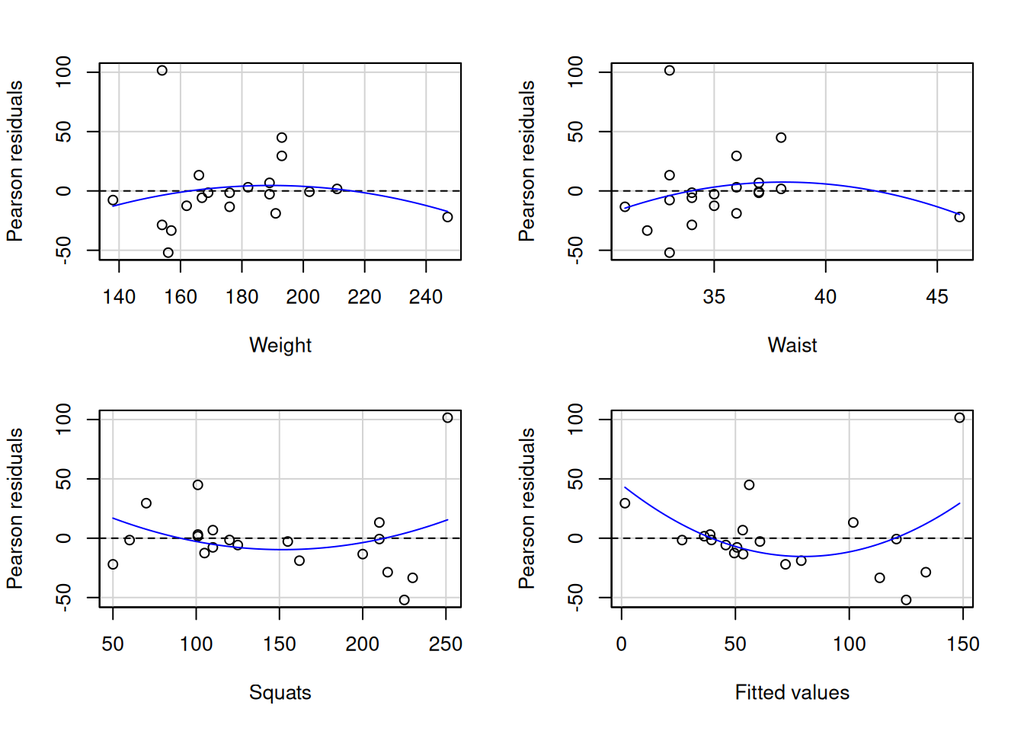

```
##            Test stat Pr(>|Test stat|)
## Weight       -0.9886          0.33853
## Waist        -1.0112          0.32796
## Squats        1.1747          0.25841
## Tukey test    2.0629          0.03912 *
## ---
## Signif. codes:  0 '***' 0.001 '**' 0.01 '*' 0.05 '.' 0.1 ' ' 1
```

```r
residualPlots(lm2)
```

*El test de Tukey por el modelo resulta significativo con probabilidad 3.9% pero ningún regresor se resulta significativo.*

*Ahora estudiamos el condicionamiento, ya que se ve que Weight y Waist están fuertemente correlacionados. Por esto cargamos la función cond()*

```r
cond                <- function(dat) {
  res               <- list()
  cordat            <- cor(dat)
  res$correlation   <- cordat
  eig               <- eigen(cordat)$values
  n                 <- length(eig)
  rk                <- sum(eig != 0)
  res$eigenvalues   <- eig
  res$rank          <- rk
  res$condition     <- eig[1] / eig[rk]
  invcor            <- solve(cordat)
  res$inverse.cor   <- invcor
  rmult             <- sqrt(1-1/(diag(invcor)))
  r2                <- rmult^2
  tol               <- 1 - r2
  vif               <- 1 / tol
  inf               <- cbind(rmult,r2,tol,vif)
  colnames(inf)     <- c("multiple corr.","R²","tolerance",
                         "var. inflation factor")
  res$inflation     <- inf
  res
}
```

```r
pr                  <- 3                                    # número de regresores
cond(lin[,c(1,2,6)])
```

```
## $correlation
##            Weight      Waist      Jumps
## Weight  1.0000000  0.8702435 -0.2262956
## Waist   0.8702435  1.0000000 -0.1914994
## Jumps  -0.2262956 -0.1914994  1.0000000
##
## $eigenvalues
## [1] 1.9610849 0.9098961 0.1290190
##
## $rank
## [1] 3
##
## $condition
## [1] 15.19997
##
## $inverse.cor
##            Weight       Waist       Jumps
## Weight  4.1843915 -3.59182643  0.25907672
## Waist  -3.5918264  4.12124445 -0.02359866
## Jumps   0.2590767 -0.02359866  1.05410878
##
## $inflation
##        multiple corr.         R² tolerance var. inflation factor
## Weight      0.8723627 0.76101663 0.2389834              4.184391
## Waist       0.8702614 0.75735484 0.2426452              4.121244
## Jumps       0.2265641 0.05133131 0.9486687              1.054109
```

*Se resulta un alto valor de inflación. Weight resulta el más correlacionado, entonces esto podría ser un argumento en favor de tirarlo de la regresión, ya que esto debería reducir la varianza de los beta también.*

*Pasamos a los varios testes, comenzando para los gráficos, y luego las pruebas de homocedasticidad y de normalidad:*

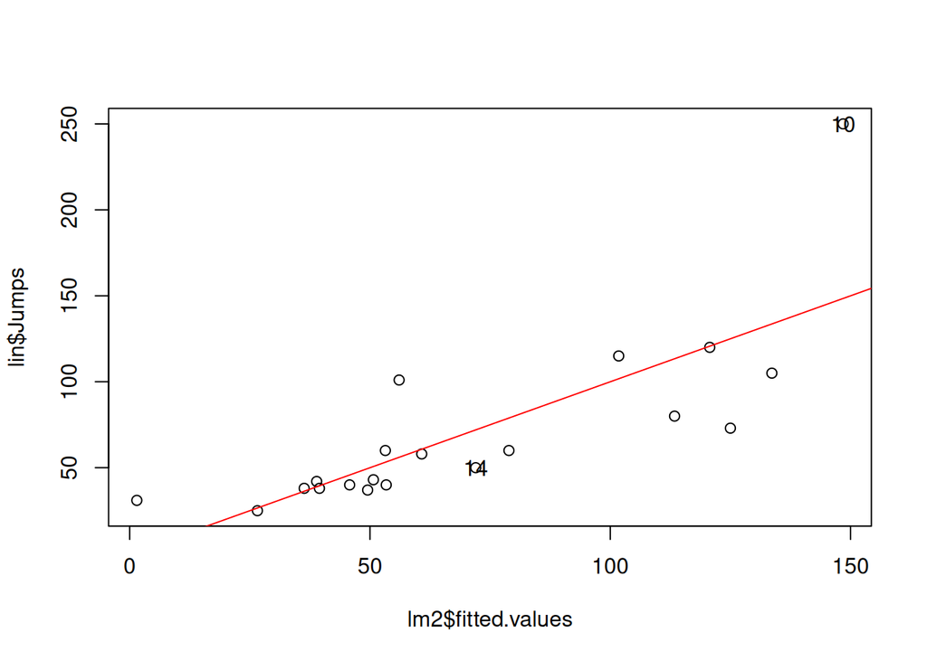

```r
plot(lm2$fitted.values,lin$Jumps)
  abline(0,1,col="red")
  text(lm2$fitted.values[c(10,14)],lin$Jumps[c(10,14)],
       lab=etiq[c(10,14)])
```

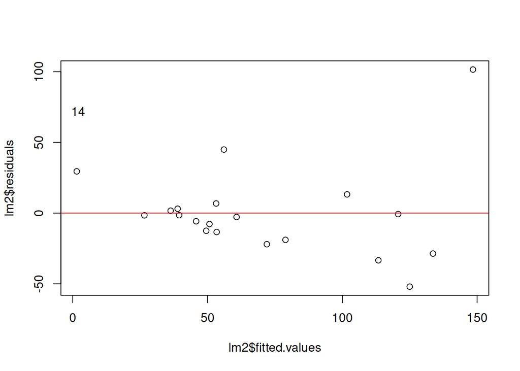

```r
plot(lm2$fitted.values,lm2$residuals)
  abline(h=0,col="red")
  text(lm2$fitted.values[c(10,14)],lin$residuals[c(10,14)],
       lab=etiq[c(10,14)])
```

```r
cat("n prueba de homocedasticidad \n")
```

```
## n prueba de homocedasticidad
```

```r
ncvTest(lm2)                                                # NCV test
```

```
## Non-constant Variance Score Test
## Variance formula: ~ fitted.values
## Chisquare = 16.23439, Df = 1, p = 5.5969e-05
```

```r
cat("n prueba de normalidad \n")
```

```
## n prueba de normalidad
```

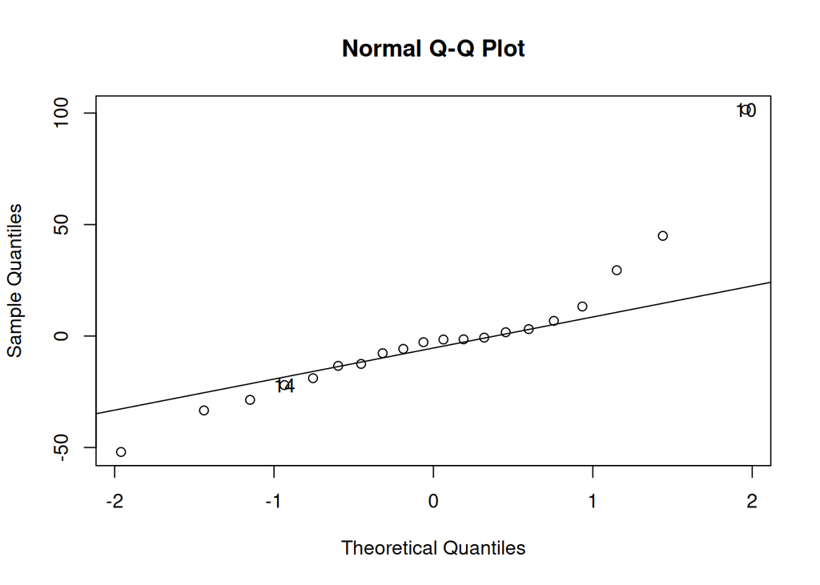

```r
qq                  <- qqnorm(lm2$residuals)
qqline(lm2$residuals)
text(qq$x[c(10,14)],qq$y[c(10,14)],lab=etiq[c(10,14)])
```

```r
shapiro.test(lm2$residuals)
```

```
##
##  Shapiro-Wilk normality test
##
## data:  lm2$residuals
## W = 0.85656, p-value = 0.006878
```

```r
shapiro.test(lm2$residuals[-c(10,14)])
```

```
##
##  Shapiro-Wilk normality test
##
## data:  lm2$residuals[-c(10, 14)]
## W = 0.96167, p-value = 0.6342
```

*La varianza no es costante. Por otro lado, la prueba de Shapiro mostrando que no se cumple con la normalidad, si se tiran las observaciones 10 y 14, resulta positiva.*

*vemos los apalancamientos*

```r
cat("\n Apalancamientos \n")
```

```
##
##  Apalancamientos
```

```r
influence(lm2)$hat                                          # hii
```

```
##          1          2          3          4          5          6          7          8          9         10         11         12         13         14         15         16         17         18         19         20
## 0.08452817 0.06863760 0.09018713 0.14995289 0.11231976 0.08381668 0.17630287 0.09378932 0.41722613 0.26277432 0.10430600 0.10784287 0.23608762 0.66785738 0.22582375 0.25630093 0.20066155 0.14934980 0.16370168 0.34853356
```

```r
cat("\n Varianza sin unidad \n")
```

```
##
##  Varianza sin unidad
```

```r
influence(lm2)$sigma                                        # sigma(i)
```

```
##        1        2        3        4        5        6        7        8        9       10       11       12       13       14       15       16       17       18       19       20
## 35.55831 35.87654 33.80030 35.75135 35.91465 35.91298 35.91944 35.88860 35.63644 18.92063 35.92039 35.73985 34.91283 34.54383 34.86291 35.92205 35.91978 34.68616 32.78555 35.83783
```

```r
cat("\n Beta sin unidad \n")
```

```
##
##  Beta sin unidad
```

```r
influence(lm2)$coefficients                                 # beta(i)
```

```
##     (Intercept)       Weight        Waist       Squats
## 1     3.2206720 -0.055171622  0.194674390 -0.008872431
## 2    -0.1385598  0.001016160  0.019936038 -0.002634621
## 3   -16.8767384 -0.045459347  0.822182318 -0.011266318
## 4    -5.4409092  0.063901773 -0.240888091  0.012500751
## 5    -1.4741792 -0.014787037  0.110315110  0.000371117
## 6     1.6227108  0.001359407 -0.035833383 -0.002941797
## 7     0.4752741  0.011720032 -0.065123953 -0.001101743
## 8    -5.1701130  0.001002313  0.109144439  0.005559498
## 9   -39.5548868 -0.227957695  2.189135264  0.011162603
## 10 -126.9645995 -0.607917724  5.750447887  0.266986000
## 11   -1.5764330 -0.001100194  0.040748342  0.001701245
## 12    1.1965646  0.010463432 -0.111703611  0.011206188
## 13   36.1015025  0.242968604 -2.068130188 -0.056047974
## 14  168.3052784  0.109869294 -5.141589379 -0.063399248
## 15   49.5558204  0.189931393 -2.022287626 -0.068583810
## 16    1.0592451 -0.003042250 -0.008894326 -0.001706638
## 17   -0.6388223  0.007477344 -0.033261193  0.002625605
## 18   -3.0493546  0.010362358  0.134987995 -0.038074878
## 19   28.8933922  0.200977820 -1.589738943 -0.079836196
## 20   -8.3163502  0.093397111 -0.309016166  0.013622870
```

```r
library(faraway)
```

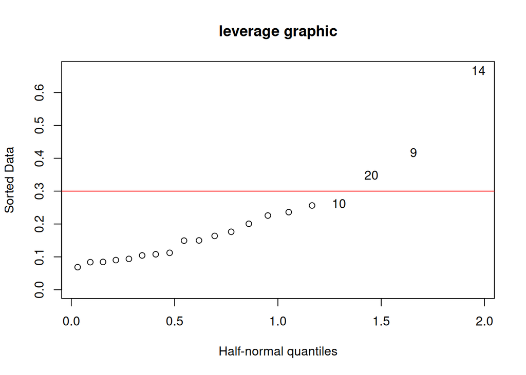

```r
halfnorm(influence(lm2)$hat,nlab=4,labs=etiq,
         main="leverage graphic")
  abline(h=2*pr/n,col="red")
```

*Varias unidades resultan con fuerte apalancamiento: el máximo apalancamiento se resulta por la unidad 14, pero la 10 influye muchísimo sobre la varianza, ya que tirando-la se reduce de la mitad. Igualmente, la 10 influye muchísimo sobre los beta.*

*Residuos estandarizados y studentizados*

```r
rstandard(lm2)                                              # residuos
```

```
##           1           2           3           4           5           6           7           8           9          10          11          12          13          14          15          16          17          18          19          20
## -0.56826607  0.20265521  1.35453302 -0.39019252 -0.08449945  0.09291638  0.05360878 -0.17417784 -0.50393838  3.40019403 -0.04507042  0.40304261 -0.94176607 -1.09759024  0.96442139 -0.02348525 -0.05071935 -1.04044584 -1.63478699 -0.27474896
```

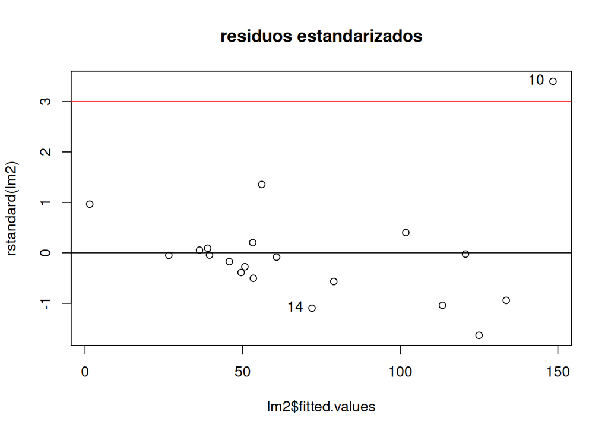

```r
plot(lm2$fitted.values,rstandard(lm2),main = "residuos estandarizados")
  abline(h=0)
  text(lm2$fitted.values[c(10,14)],rstandard(lm2)[c(10,14)],
       lab=etiq[c(10,14)],pos=2)
  abline(h=3,col="red")
  abline(h=-3,col="red")
```

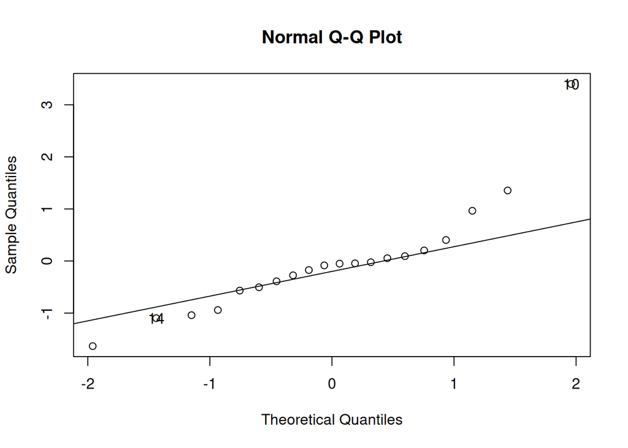

```r
res                 <- qqnorm(rstandard(lm2))               # q-q plot
  qqline(rstandard(lm2))
  text(res$x[c(10,14)],res$y[c(10,14)],lab=etiq[c(10,14)])
```

```r
shapiro.test(rstandard(lm2))                                # no es normal
```

```
##
##  Shapiro-Wilk normality test
##
## data:  rstandard(lm2)
## W = 0.84832, p-value = 0.004997
```

```r
shapiro.test(rstandard(lm2)[-c(10,14)])                     # si es normal
```

```
##
##  Shapiro-Wilk normality test
##
## data:  rstandard(lm2)[-c(10, 14)]
## W = 0.96255, p-value = 0.6516
```

```r
cat("\n residuos studentizados \n")
```

```
##
##  residuos studentizados
```

```r
rstud               <- rstudent(lm2)
rstud
```

```
##           1           2           3           4           5           6           7           8           9          10          11          12          13          14          15          16          17          18          19          20
## -0.55585928  0.19647238  1.39387316 -0.37961273 -0.08183450  0.08999018  0.05191114 -0.16880708 -0.49185525  6.25060972 -0.04364202  0.39224056 -0.93823629 -1.10515717  0.96218239 -0.02273989 -0.04911275 -1.04331988 -1.73433473 -0.26665431
```

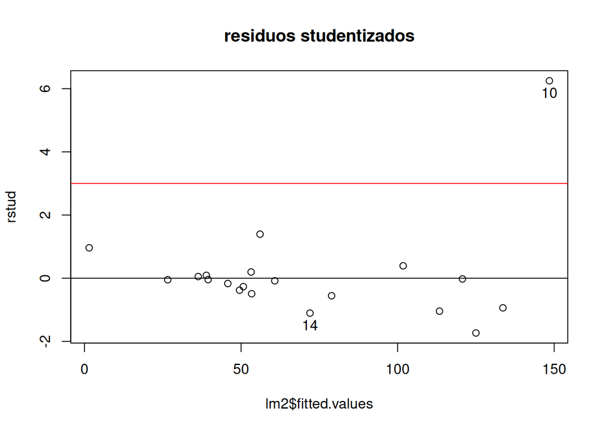

```r
plot(lm2$fitted.values,rstud,main="residuos studentizados")
  abline(h=0)
  text(lm2$fitted.values[c(10,14)],rstud[c(10,14)],lab=etiq[c(10,14)]
       ,pos=1)
  abline(h=3,col="red")
  abline(h=-3,col="red")
```

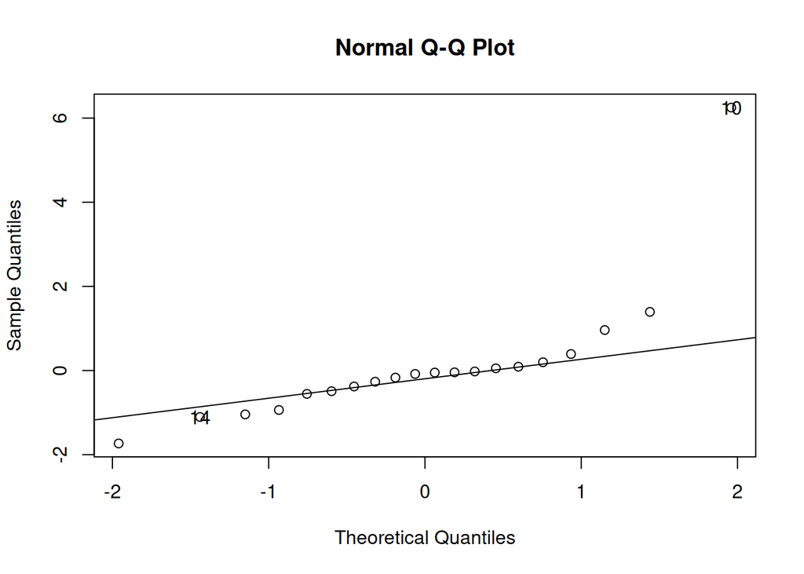

```r
rst                 <- qqnorm(rstud)                        # normal probability plot
  qqline(rstud)
  text(rst$x[c(10,14)],rst$y[c(10,14)],lab=etiq[c(10,14)])
```

```r
shapiro.test(rstud)                                         # no es normal
```

```
##
##  Shapiro-Wilk normality test
##
## data:  rstud
## W = 0.65246, p-value = 1.083e-05
```

```r
shapiro.test(rstud[-c(10,14)])                              # si es normal
```

```
##
##  Shapiro-Wilk normality test
##
## data:  rstud[-c(10, 14)]
## W = 0.95688, p-value = 0.5427
```

*Tanto los residuos estandarizados como los studentizados faltan de normalidad debido a la observación 10.*

*En fin, la distancia de Cook resulta la siguiente:*

```r
# distancia de Cook
cd                  <- cooks.distance(lm2)
mcd                 <- mean(cd)                             # distancia promedio
cat(paste("\n distancia de Cook promedio =",mcd,"\n"))
```

```
##
##  distancia de Cook promedio = 0.103647305297709
```

```r
round(cd,3)                                                 # distancia de Cook
```

```
##     1     2     3     4     5     6     7     8     9    10    11    12    13    14    15    16    17    18    19    20
## 0.007 0.001 0.045 0.007 0.000 0.000 0.000 0.001 0.045 1.030 0.000 0.005 0.069 0.606 0.068 0.000 0.000 0.048 0.131 0.010
```

```r
cat("\n Puntos mas lejos de 3 promedios: ")
```

```
##
##  Puntos mas lejos de 3 promedios:
```

```r
which(cd>3*mcd)
```

```
## 10 14
## 10 14
```

```r
cat("\n Puntos mas lejos de 4 veces los regresores: ")
```

```
##
##  Puntos mas lejos de 4 veces los regresores:
```

```r
which(cd>4/n)
```

```
## 10 14
## 10 14
```

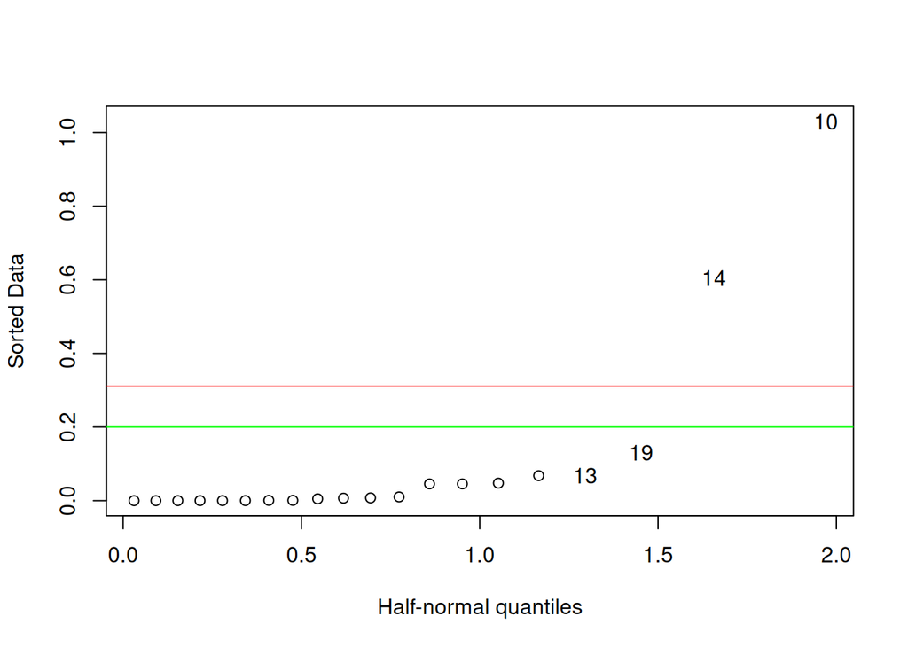

```r
halfnorm(cd,nlab=4,labs=etiq)
  abline(h=3*mcd,col="red")
  abline(h=4/n,col="green")
```

Se resulta que las unidades con distancia de Cook excesiva son 10 y 14. Se supone que el modelo sea particularmente influenciado sobre todo para 10, pero también 14 que, a parte el apalancamiento, tiene fuerte influencia sobre los beta.

## 3 Si el modelo no cumple

con la linealidad, intentar con el cuadrado o la raíz cuadrada del/los regresor/es que no cumple/n.

```r
lm6                 <- lm(Jumps ~ Weight+I(sqrt(Weight))+Waist+
                          I(sqrt(Waist))+Squats+I(Squats^(-4)),data=lin)
sum.lm(lm6)
```

```
##
## Call:
## lm(formula = Jumps ~ Weight + I(sqrt(Weight)) + Waist + I(sqrt(Waist)) +
##     Squats + I(Squats^(-4)), data = lin)
##
## Residuals:
##     Min      1Q  Median      3Q     Max
## -51.189 -12.384  -2.072   3.519 100.646
##
## Coefficients:
##                                 2.5 %     97.5 % Std. Error t value Pr(>|t|)
## (Intercept)     -3.480e+03 -1.415e+04  7.186e+03  4.937e+03  -0.705  0.49336
## Weight          -3.541e+00 -4.234e+01  3.526e+01  1.796e+01  -0.197  0.84676
## I(sqrt(Weight))  6.373e+01 -9.384e+02  1.066e+03  4.639e+02   0.137  0.89283
## Waist           -5.435e+01 -4.813e+02  3.726e+02  1.976e+02  -0.275  0.78763
## I(sqrt(Waist))   8.622e+02 -4.111e+03  5.835e+03  2.302e+03   0.375  0.71403
## Squats           8.929e-01  4.149e-01  1.371e+00  2.212e-01   4.036  0.00141 **
## I(Squats^(-4))   8.213e+07 -1.291e+09  1.455e+09  6.354e+08   0.129  0.89914
## ---
## Signif. codes:  0 '***' 0.001 '**' 0.01 '*' 0.05 '.' 0.1 ' ' 1
##
## Residual standard error: 37.29 on 13 degrees of freedom
## Multiple R-squared:  0.6381, Adjusted R-squared:  0.4711
## F-statistic: 3.821 on 6 and 13 DF,  p-value: 0.02037
```

```r
step(lm6,direction="backward")
```

```
## Start:  AIC=150.14
## Jumps ~ Weight + I(sqrt(Weight)) + Waist + I(sqrt(Waist)) + Squats +
##     I(Squats^(-4))
##
##                   Df Sum of Sq   RSS    AIC
## - I(Squats^(-4))   1      23.2 18102 148.16
## - I(sqrt(Weight))  1      26.3 18105 148.16
## - Weight           1      54.1 18133 148.19
## - Waist            1     105.2 18184 148.25
## - I(sqrt(Waist))   1     195.1 18274 148.35
## <none>                         18079 150.14
## - Squats           1   22648.9 40728 164.38
##
## Step:  AIC=148.16
## Jumps ~ Weight + I(sqrt(Weight)) + Waist + I(sqrt(Waist)) + Squats
##
##                   Df Sum of Sq   RSS    AIC
## - I(sqrt(Weight))  1      48.4 18151 146.22
## - Weight           1      88.1 18190 146.26
## - Waist            1      94.7 18197 146.27
## - I(sqrt(Waist))   1     223.1 18325 146.41
## <none>                         18102 148.16
## - Squats           1   28635.9 46738 165.13
##
## Step:  AIC=146.21
## Jumps ~ Weight + Waist + I(sqrt(Waist)) + Squats
##
##                  Df Sum of Sq   RSS    AIC
## - Waist           1     761.5 18912 145.04
## - I(sqrt(Waist))  1    1205.8 19357 145.50
## <none>                        18151 146.22
## - Weight          1    3360.5 21511 147.61
## - Squats          1   28846.7 46997 163.24
##
## Step:  AIC=145.04
## Jumps ~ Weight + I(sqrt(Waist)) + Squats
##
##                  Df Sum of Sq   RSS    AIC
## <none>                        18912 145.04
## - Weight          1    3512.4 22425 146.44
## - I(sqrt(Waist))  1    7963.4 26876 150.06
## - Squats          1   28486.6 47399 161.41
```

```
##
## Call:
## lm(formula = Jumps ~ Weight + I(sqrt(Waist)) + Squats, data = lin)
##
## Coefficients:
##    (Intercept)          Weight  I(sqrt(Waist))          Squats
##       -956.262          -1.136         186.386           0.835
```

```r
lm7                 <- lm(Jumps ~ Weight + I(sqrt(Waist)) + Squats,
                          data = lin)
sum.lm(lm7)
```

```
##
## Call:
## lm(formula = Jumps ~ Weight + I(sqrt(Waist)) + Squats, data = lin)
##
## Residuals:
##     Min      1Q  Median      3Q     Max
## -52.075 -14.520  -3.213   3.145 100.944
##
## Coefficients:
##                                2.5 %     97.5 % Std. Error t value Pr(>|t|)
## (Intercept)     -956.2623 -1700.2809  -212.2437   350.9678  -2.725 0.014995 *
## Weight            -1.1361    -2.5333     0.2611     0.6591  -1.724 0.104008
## I(sqrt(Waist))   186.3855    34.1585   338.6125    71.8084   2.596 0.019515 *
## Squats             0.8350     0.4744     1.1955     0.1701   4.909 0.000157 ***
## ---
## Signif. codes:  0 '***' 0.001 '**' 0.01 '*' 0.05 '.' 0.1 ' ' 1
##
## Residual standard error: 34.38 on 16 degrees of freedom
## Multiple R-squared:  0.6214, Adjusted R-squared:  0.5505
## F-statistic: 8.755 on 3 and 16 DF,  p-value: 0.001147
```

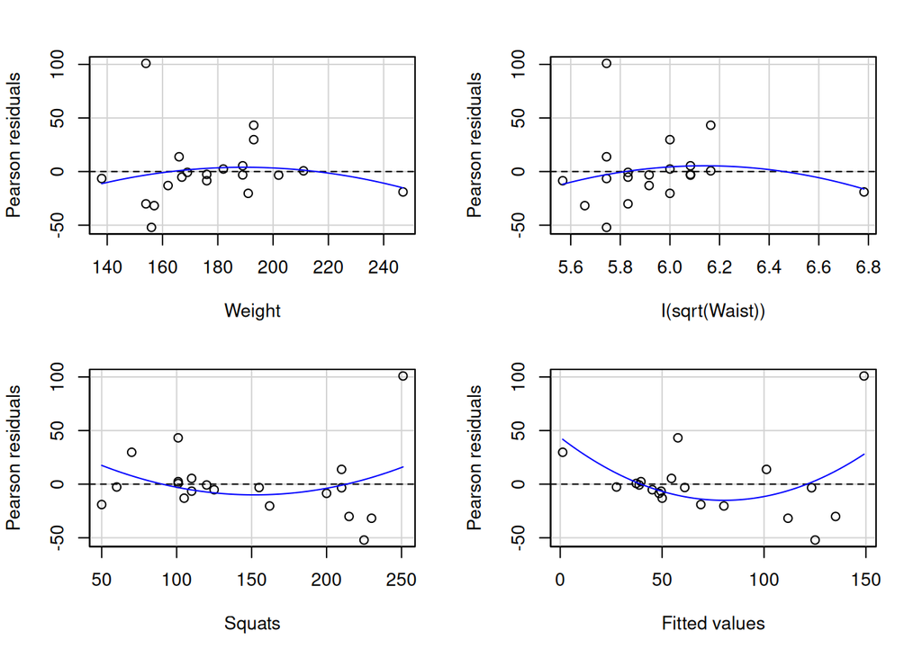

```
##                Test stat Pr(>|Test stat|)
## Weight           -0.8211          0.42446
## I(sqrt(Waist))   -0.7933          0.43998
## Squats            1.2136          0.24365
## Tukey test        2.0005          0.04545 *
## ---
## Signif. codes:  0 '***' 0.001 '**' 0.01 '*' 0.05 '.' 0.1 ' ' 1
```

```r
residualPlots(lm7)
```

*Incluyendo raízes cuadradas, la calidad del modelo mejora, pero al precio de una no significatividad de los parámetros. Aplicando el modelo backward se resulta una mejoría, pero la procedura backward reduce la mejoría a solo la raíz de Waist. El Weight todavía no resulta significativo. Por otro lado, se parece que la falta de ajuste dependa de la unidad 10.*

## 4 Si se encuentran puntos aberrantes,

recorrer el modelo sin esos y hacer de nuevo todos los test (inclusiva la no-linealidad).

```r
linr                <- lin[c(-10,-14),]                     # se tiran 10 y 14
nr                  <- dim(linr)
etiqr               <- rownames(linr)
lmr1                <- lm(Jumps~.,data=linr)
sum.lm(lmr1)
```

```
##
## Call:
## lm(formula = Jumps ~ ., data = linr)
##
## Residuals:
##     Min      1Q  Median      3Q     Max
## -23.373 -10.422  -1.516   4.554  35.322
##
## Coefficients:
##                           2.5 %    97.5 % Std. Error t value Pr(>|t|)
## (Intercept) -428.3169 -702.2385 -154.3953   125.7206  -3.407 0.005203 **
## Weight        -0.6295   -1.4348    0.1758     0.3696  -1.703 0.114276
## Waist         14.3870    5.5319   23.2422     4.0642   3.540 0.004071 **
## Pulse          0.1190   -1.2418    1.4797     0.6245   0.190 0.852119
## Pulls          0.7159   -1.7542    3.1861     1.1337   0.632 0.539552
## Squats         0.5820    0.3376    0.8264     0.1122   5.189 0.000226 ***
## ---
## Signif. codes:  0 '***' 0.001 '**' 0.01 '*' 0.05 '.' 0.1 ' ' 1
##
## Residual standard error: 17.96 on 12 degrees of freedom
## Multiple R-squared:  0.7556, Adjusted R-squared:  0.6538
## F-statistic: 7.422 on 5 and 12 DF,  p-value: 0.002195
```

```r
lmr1b               <- step(lmr1,direction = "backward")
```

```
## Start:  AIC=108.68
## Jumps ~ Weight + Waist + Pulse + Pulls + Squats
##
##          Df Sum of Sq     RSS    AIC
## - Pulse   1      11.7  3882.9 106.73
## - Pulls   1     128.7  3999.9 107.27
## <none>                 3871.2 108.68
## - Weight  1     935.8  4807.0 110.57
## - Waist   1    4042.6  7913.8 119.55
## - Squats  1    8686.9 12558.1 127.86
##
## Step:  AIC=106.73
## Jumps ~ Weight + Waist + Pulls + Squats
##
##          Df Sum of Sq     RSS    AIC
## - Pulls   1     126.9  4009.9 105.31
## <none>                 3882.9 106.73
## - Weight  1     979.8  4862.8 108.78
## - Waist   1    4037.2  7920.2 117.56
## - Squats  1    8719.5 12602.4 125.92
##
## Step:  AIC=105.31
## Jumps ~ Weight + Waist + Squats
##
##          Df Sum of Sq     RSS    AIC
## <none>                 4009.9 105.31
## - Weight  1     886.4  4896.2 106.91
## - Waist   1    3910.4  7920.3 115.56
## - Squats  1   11817.7 15827.6 128.03
```

```r
lmr2                <- lm(Jumps ~ Weight + Waist + Squats,data=linr)
sum.lm(lmr2)
```

```
##
## Call:
## lm(formula = Jumps ~ Weight + Waist + Squats, data = linr)
##
## Residuals:
##     Min      1Q  Median      3Q     Max
## -22.602  -7.929  -1.188   4.436  34.569
##
## Coefficients:
##                             2.5 %     97.5 % Std. Error t value Pr(>|t|)
## (Intercept) -406.09088 -629.89073 -182.29104  104.34597  -3.892  0.00163 **
## Weight        -0.59773   -1.32649    0.13103    0.33978  -1.759  0.10038
## Waist         13.84951    5.81042   21.88860    3.74820   3.695  0.00240 **
## Squats         0.61291    0.40826    0.81756    0.09542   6.423 1.59e-05 ***
## ---
## Signif. codes:  0 '***' 0.001 '**' 0.01 '*' 0.05 '.' 0.1 ' ' 1
##
## Residual standard error: 16.92 on 14 degrees of freedom
## Multiple R-squared:  0.7469, Adjusted R-squared:  0.6927
## F-statistic: 13.77 on 3 and 14 DF,  p-value: 0.0001845
```

```r
lmr3                <- lm(Jumps ~ Waist + Squats,data=linr)
sum.lm(lmr3)
```

```
##
## Call:
## lm(formula = Jumps ~ Waist + Squats, data = linr)
##
## Residuals:
##     Min      1Q  Median      3Q     Max
## -25.891  -8.902  -2.096   3.333  37.109
##
## Coefficients:
##                             2.5 %     97.5 % Std. Error t value Pr(>|t|)
## (Intercept) -331.46346 -548.38580 -114.54113  101.77221  -3.257  0.00531 **
## Waist          8.90773    3.26142   14.55404    2.64905   3.363  0.00427 **
## Squats         0.56298    0.35569    0.77027    0.09725   5.789 3.57e-05 ***
## ---
## Signif. codes:  0 '***' 0.001 '**' 0.01 '*' 0.05 '.' 0.1 ' ' 1
##
## Residual standard error: 18.07 on 15 degrees of freedom
## Multiple R-squared:  0.6909, Adjusted R-squared:  0.6497
## F-statistic: 16.77 on 2 and 15 DF,  p-value: 0.0001497
```

```r
anova(lmr3,lmr2)
```

```
## Analysis of Variance Table
##
## Model 1: Jumps ~ Waist + Squats
## Model 2: Jumps ~ Weight + Waist + Squats
##   Res.Df    RSS Df Sum of Sq      F Pr(>F)
## 1     15 4896.2
## 2     14 4009.9  1    886.37 3.0947 0.1004
```

```r
Anova(lmr3)
```

```
## Anova Table (Type II tests)
##
## Response: Jumps
##            Sum Sq Df F value    Pr(>F)
## Waist      3690.9  1  11.307  0.004273 **
## Squats    10938.6  1  33.511 3.573e-05 ***
## Residuals  4896.2 15
## ---
## Signif. codes:  0 '***' 0.001 '**' 0.01 '*' 0.05 '.' 0.1 ' ' 1
```

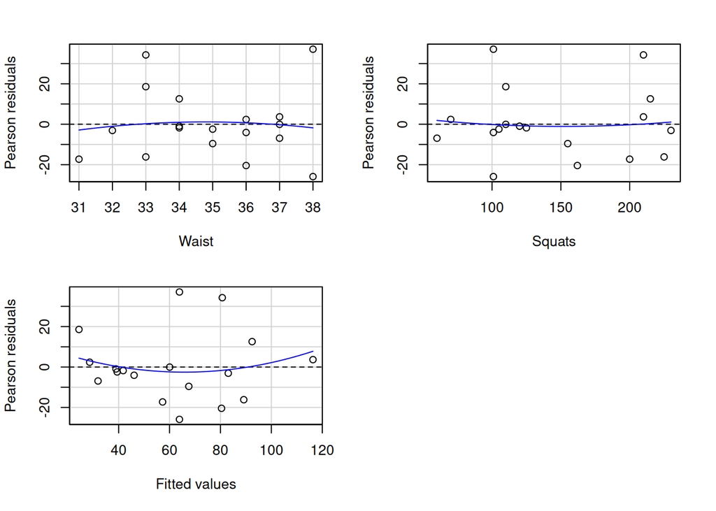

```
##            Test stat Pr(>|Test stat|)
## Waist        -0.2599           0.7987
## Squats        0.1794           0.8602
## Tukey test    0.6255           0.5317
```

```r
residualPlots(lmr3)
```

*El modelo conseguido con el método backward en este caso se puede pensar de reducirlo a solo dos regresores, ya que la variación de residuos es mucho menor que la de antes y igualmente se estará reduciendo la varianza de los beta. Ambos los parametros son significativos, y el test de Tucker segura que no hay falta de ajuste.*

```r
pr                  <- 2                                    # número de regresores
cond(lin[,c(2,6)])
```

```
## $correlation
##            Waist      Jumps
## Waist  1.0000000 -0.1914994
## Jumps -0.1914994  1.0000000
##
## $eigenvalues
## [1] 1.1914994 0.8085006
##
## $rank
## [1] 2
##
## $condition
## [1] 1.473715
##
## $inverse.cor
##           Waist     Jumps
## Waist 1.0380680 0.1987894
## Jumps 0.1987894 1.0380680
##
## $inflation
##       multiple corr.         R² tolerance var. inflation factor
## Waist      0.1914994 0.03667201  0.963328              1.038068
## Jumps      0.1914994 0.03667201  0.963328              1.038068
```

*en este caso no hay ninguna inflación*

*Pasamos a los varios testes, comenzando para los gráficos, y luego las pruebas de homocedasticidad y de normalidad:*

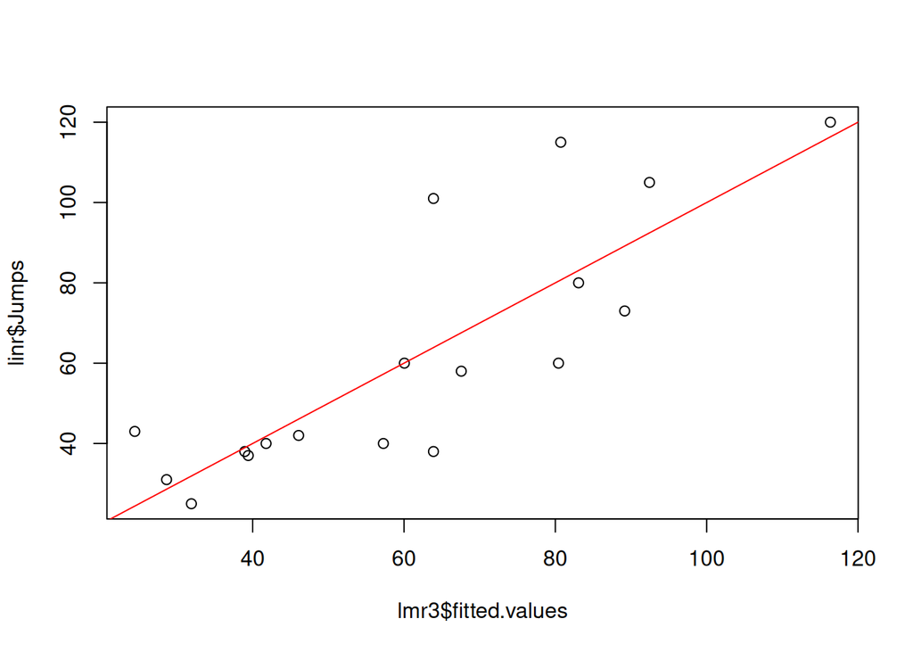

```r
plot(lmr3$fitted.values,linr$Jumps)
  abline(0,1,col="red")
```

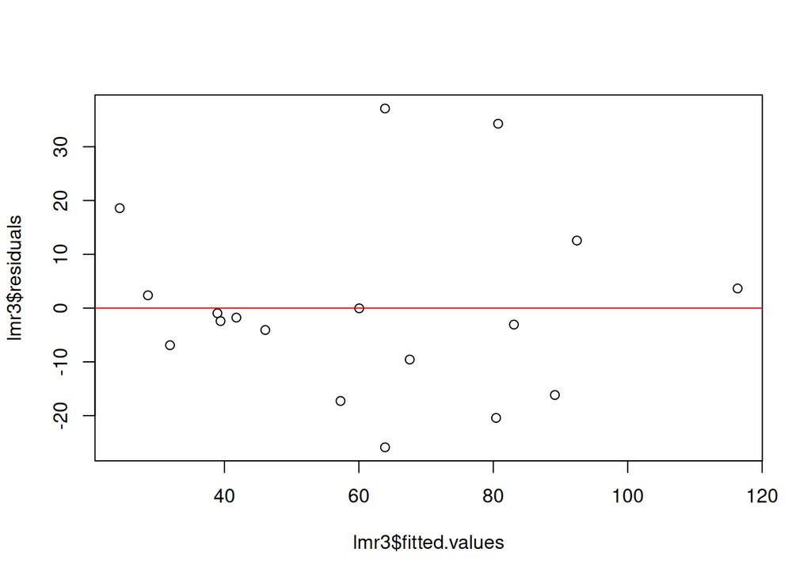

```r
plot(lmr3$fitted.values,lmr3$residuals)
  abline(h=0,col="red")
```

```r
cat("\n prueba de homocedasticidad \n")
```

```
##
##  prueba de homocedasticidad
```

```r
ncvTest(lmr3)                                                # NCV test
```

```
## Non-constant Variance Score Test
## Variance formula: ~ fitted.values
## Chisquare = 0.6768318, Df = 1, p = 0.41068
```

```r
cat("n prueba de normalidad \n")
```

```
## n prueba de normalidad
```

```r
shapiro.test(lmr3$residuals)                                 # NCV test
```

```
##
##  Shapiro-Wilk normality test
##
## data:  lmr3$residuals
## W = 0.92254, p-value = 0.1434
```

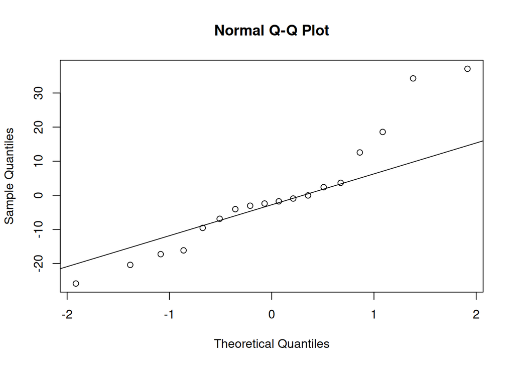

```r
qq                  <- qqnorm(lmr3$residuals)
qqline(lmr3$residuals)
```

*Como previsto, la varianza ahora es costante y la normalidad se cumple, aún el qqplot mostra unas unidades desplazadas.*

*Vemos los apalancamientos:*

```r
cat("\n Apalancamientos \n")
```

```
##
##  Apalancamientos
```

```r
influence(lmr3)$hat                                         # hii
```

```
##          1          2          3          4          5          6          7          8          9         11         12         13         15         16         17         18         19         20
## 0.10493291 0.11352932 0.18462694 0.09987069 0.05904729 0.09147553 0.18462694 0.10426908 0.27156123 0.11527534 0.13916922 0.15389404 0.16727365 0.39576446 0.18972535 0.21348453 0.17447730 0.23699619
```

```r
cat("\n Varianza sin unidad \n")
```

```
##
##  Varianza sin unidad
```

```r
influence(lmr3)$sigma                                       # sigma(i)
```

```
##        1        2        3        4        5        6        7        8        9       11       12       13       15       16       17       18       19       20
## 17.78942 18.70111 15.13601 18.68868 18.51434 18.66616 17.05891 18.69442 17.90190 18.69914 15.88116 18.34161 18.68816 18.65893 18.58852 18.67822 18.08672 17.81608
```

```r
cat("\n Beta sin unidad \n")
```

```
##
##  Beta sin unidad
```

```r
influence(lmr3)$coefficients                                # beta(i)
```

```
##     (Intercept)        Waist        Squats
## 1   26.54770407 -0.701886627 -2.267562e-02
## 2    0.05134673 -0.001568740  2.138904e-06
## 3  -69.86437972  2.038280677  8.042734e-03
## 4   -2.26407274  0.047880588  3.045142e-03
## 5    2.01393817 -0.060459731 -3.215069e-03
## 6   -0.47184094 -0.008027736  3.469848e-03
## 7   48.74561021 -1.422144385 -5.611557e-03
## 8   -2.46525426  0.058962777  2.034003e-03
## 9  -50.89411303  1.391155265  6.645948e-03
## 11  -1.46060347  0.034812471  1.268984e-03
## 12  11.87141340 -0.434986288  3.821675e-02
## 13  -9.29335759  0.192252132  2.344752e-02
## 15   2.14058474 -0.036923659 -4.770749e-03
## 16 -18.02337439  0.453665216  1.728293e-02
## 17  -1.17495432 -0.032448380  1.265971e-02
## 18  -2.74034015  0.089446375 -4.152604e-03
## 19   0.27311016  0.074325830 -2.729702e-02
## 20  57.91728195 -1.422878703 -4.719105e-02
```

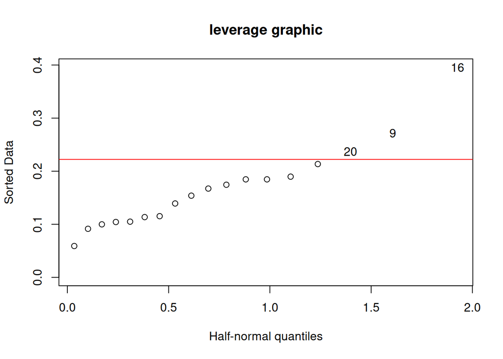

```r
library(faraway)
halfnorm(influence(lmr3)$hat,nlab=3,labs=etiqr,
         main="leverage graphic")
  abline(h=2*pr/nr,col="red")
```

*Las unidad 16,9 y 20 siguen tener un fuerte apalancamiento , pero 3, 7 y9 influyen fuertemente sobre los beta.*

*Residuos estandarizados y studentizados*

```r
rstandard(lmr3)                                             # residuos
```

```
##            1            2            3            4            5            6            7            8            9           11           12           13           15           16           17           18           19           20
## -1.194520491 -0.002965937  2.274631338 -0.141186336 -0.546012381 -0.236683914 -1.587050411 -0.103629222 -1.120130792 -0.056318747  2.045155491  0.755758415  0.144145974  0.260003202 -0.424361539 -0.191569831 -0.984585168  1.177355057
```

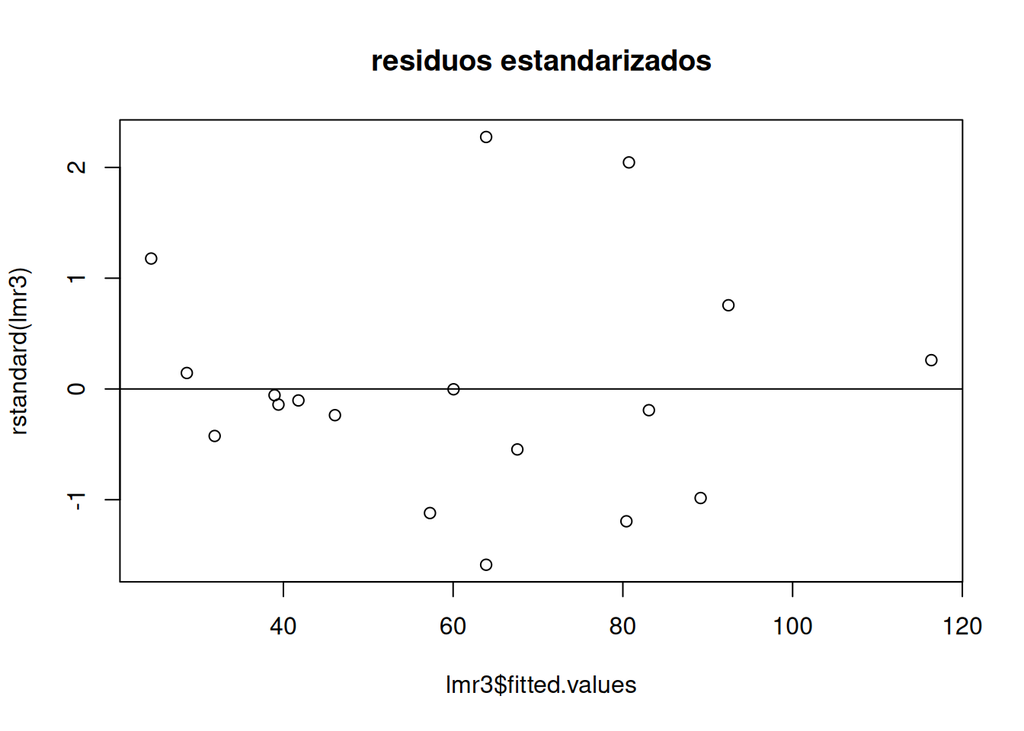

```r
plot(lmr3$fitted.values,rstandard(lmr3),main = "residuos estandarizados")
  abline(h=0)
  abline(h=3,col="red")
  abline(h=-3,col="red")
```

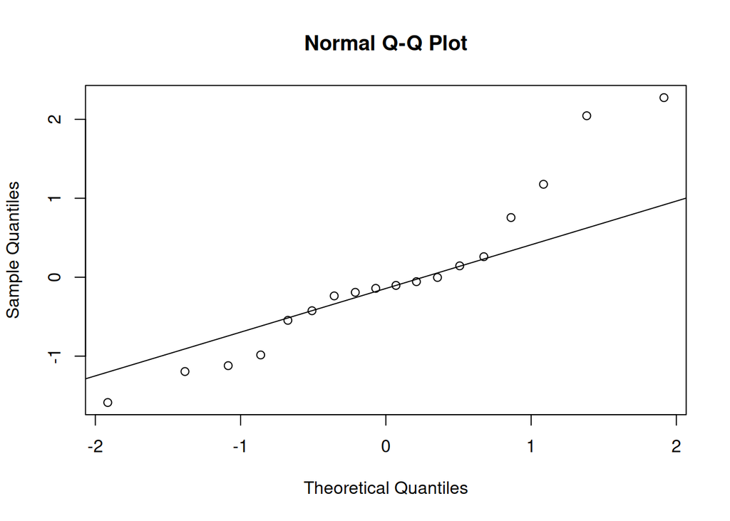

```r
res                 <- qqnorm(rstandard(lmr3))              # q-q plot
  qqline(rstandard(lmr3))
```

```r
shapiro.test(rstandard(lmr3))                                # no es normal
```

```
##
##  Shapiro-Wilk normality test
##
## data:  rstandard(lmr3)
## W = 0.92594, p-value = 0.1647
```

```r
cat("\n residuos studentizados \n")
```

```
##
##  residuos studentizados
```

```r
rstud               <- rstudent(lmr3)
rstud
```

```
##            1            2            3            4            5            6            7            8            9           11           12           13           15           16           17           18           19           20
## -1.213159113 -0.002865369  2.715097944 -0.136489681 -0.532819625 -0.229086560 -1.680835970 -0.100151197 -1.130460863 -0.054414832  2.326645034  0.744443021  0.139354792  0.251754900 -0.412455542 -0.185300856 -0.983511197  1.193936500
```

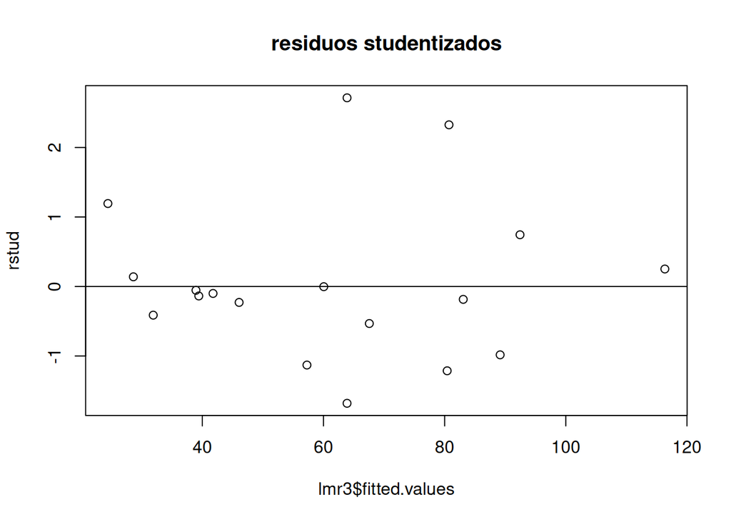

```r
plot(lmr3$fitted.values,rstud,main="residuos studentizados")
  abline(h=0)
  abline(h=3,col="red")
  abline(h=-3,col="red")
```

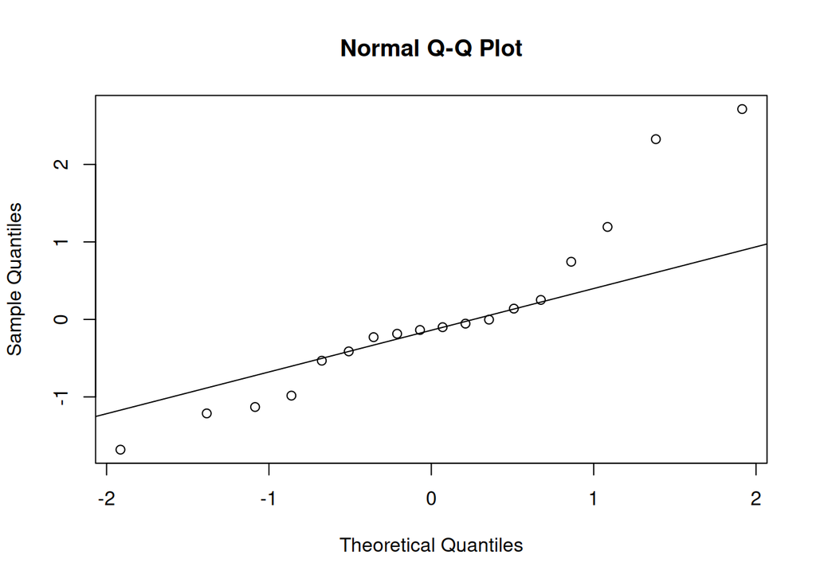

```r
rst                 <- qqnorm(rstud)                        # normal probability plot
  qqline(rstud)
```

```r
shapiro.test(rstud)                                         # no es normal
```

```
##
##  Shapiro-Wilk normality test
##
## data:  rstud
## W = 0.90661, p-value = 0.07499
```

*Tanto los residuos estandarizados como los studentizados resultan normalmente distribuidos, los studentizados a penas, debido a la unidad 3.*

*En fin, la distancia de Cook resulta la siguiente:*

```r
# distancia de Cook
cd                  <- cooks.distance(lmr3)
mcd                 <- mean(cd)                             # distancia promedio
cat(paste("\n distancia de Cook promedio =",mcd,"\n"))
```

```
##
##  distancia de Cook promedio = 0.0726155531144445
```

```r
round(cd,3)                                                 # distancia de Cook
```

```
##     1     2     3     4     5     6     7     8     9    11    12    13    15    16    17    18    19    20
## 0.056 0.000 0.391 0.001 0.006 0.002 0.190 0.000 0.156 0.000 0.225 0.035 0.001 0.015 0.014 0.003 0.068 0.144
```

```r
cat("\n Puntos mas lejos de 3 promedios: ")
```

```
##
##  Puntos mas lejos de 3 promedios:
```

```r
which(cd>3*mcd)
```

```
##  3 12
##  3 11
```

```r
cat("\n Puntos mas lejos de 4 veces los regresores: ")
```

```
##
##  Puntos mas lejos de 4 veces los regresores:
```

```r
which(cd>4/nr)
```

```
##  3 12
##  3 11
```

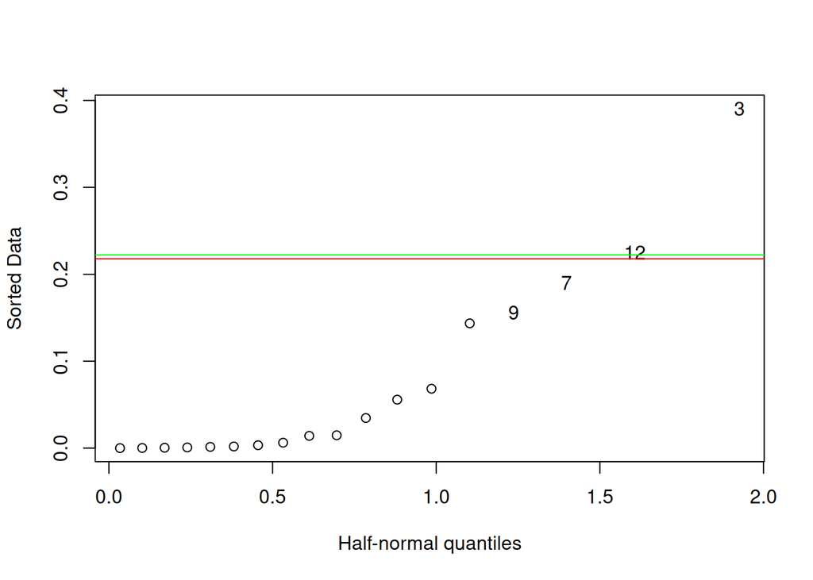

```r
halfnorm(cd,nlab=4,labs=etiqr)
  abline(h=3*mcd,col="red")
  abline(h=4/nr,col="green")
```

Efectivamente, la unidad 3 parece aberrante, pero no seguimos tirando unidades. Ya se han cumplido con casi todos los presupuestos, sino esta distancia de Cook. Por lo tanto se considera el modelo suficientemente ben definido.

Sigue estar el problema si preferir los 3 regresores proporcionados para la procedura stepwise o solo 2 considerando no significativa la differencia entre modelos.

## 5 Eligir un archivo

de datos con no mas que 100 observaciones y solo variables cuantitativas (no más que 10) y cargar-lo.

*Lo reservo a vosotros*

## 6 Escribir un reporte,

incluyendo los resultados y los gráficos relevantes (empleando las opciones echo= y include= en el encabezamiento de los pedazos de Rmarkdown), comentando los resultados conseguidos.

*Lo reservo a vosotros*

## 7 guardar los datos, los archivos .Rmd y .html y enviar todos a sergio@camiz.it dentro del 18 de Mayo.